# Discriminant Analysis Apples Quality

2024-04-25

```r
library(MASS)
```

```r
library(ggplot2)
library(memisc)
library(ROCR)
library(dplyr)
library(klaR)
```

#### Calling the apples quality dataset and converting the necessery columns into factors

```r
apples <- read.csv("D:/Rutgers/R2nd Semester/Multivariate/apple2.csv",row.names=1)
apples
```

```
##           Size      Weight   Sweetness Crunchiness   Juiciness    Ripeness
## 0  -3.97004852 -2.51233638  5.34632961 -1.01200871  1.84490036  0.32983980
## 1  -1.19521719 -2.83925653  3.66405876  1.58823231  0.85328580  0.86753008
## 2  -0.29202386 -1.35128199 -1.73842916 -0.34261593  2.83863551 -0.03803333
## 3  -0.65719577 -2.27162661  1.32487385 -0.09787472  3.63797049 -3.41376134
## 4   1.36421682 -1.29661188 -0.38465821 -0.55300577  3.03087435 -1.30384943
## 5  -3.42539975 -1.40908220 -1.91351120 -0.55577486 -3.85307147  1.91461592
## 6   1.33160574  1.63595571  0.87597424 -1.67779794  3.10634445 -1.84741673
## 7  -1.99546210 -0.42895848  1.53064358 -0.74297168  0.15883400  0.97443786
## 8  -3.86763223 -3.73451358  0.98642907 -1.20765455  2.29287292  4.08092079
## 9  -0.72798271 -0.44282035 -4.09222283  0.59751292  0.39371426  1.62085677
## 10 -2.69933629 -1.32950699 -1.41850685 -0.62554577  2.37107437  3.40316452
## 11  2.45095984 -0.56417741 -1.63504073  0.94239987 -2.08731667  1.21432169
## 12 -0.17081172 -1.86727114 -1.77184473  2.41315532 -3.09455474 -0.62488438
## 13 -1.34553054 -1.62370112  2.04414375  1.75481293  0.99756709  0.43417986
```

[output cut: 89 more lines]

```r
apples4 <- apples[, c("Size", "Weight", "Crunchiness", "Sweetness", "Juiciness", "Ripeness", "Acidity","Quality")]

apples4[apples4 == "?"] <- NA
apples4$Quality <- ifelse(test=apples4$Quality =="good", yes="good", no="bad")
apples4$Quality <- as.factor(apples4$Quality)

str(apples4)
```

```
## 'data.frame':    51 obs. of  8 variables:
##  $ Size       : num  -3.97 -1.195 -0.292 -0.657 1.364 ...
##  $ Weight     : num  -2.51 -2.84 -1.35 -2.27 -1.3 ...
##  $ Crunchiness: num  -1.012 1.5882 -0.3426 -0.0979 -0.553 ...
##  $ Sweetness  : num  5.346 3.664 -1.738 1.325 -0.385 ...
##  $ Juiciness  : num  1.845 0.853 2.839 3.638 3.031 ...
##  $ Ripeness   : num  0.33 0.868 -0.038 -3.414 -1.304 ...
##  $ Acidity    : num  -0.492 -0.723 2.622 0.791 0.502 ...
##  $ Quality    : Factor w/ 2 levels "bad","good": 2 2 1 2 2 1 2 2 1 1 ...
```

### Performing LDA on the actual data without training it

```r
rg <- lda(formula = Quality ~ ., data = apples4)
rg
```

```
## Call:
## lda(Quality ~ ., data = apples4)
##
## Prior probabilities of groups:
##       bad      good
## 0.4901961 0.5098039
##
## Group means:
##            Size     Weight Crunchiness  Sweetness Juiciness   Ripeness
## bad  -0.8798124 -0.7784901   0.8729947 -1.5212753 0.3332063  1.2179101
## good -0.2113636 -1.1269079   1.3925131  0.6269029 1.3903412 -0.5094224
##         Acidity
## bad  0.02174279
## good 0.04604762
##
## Coefficients of linear discriminants:
##                      LD1
## Size         0.480032112
## Weight       0.122701633
## Crunchiness  0.252393274
## Sweetness    0.559209486
## Juiciness    0.273022109
## Ripeness     0.005040876
## Acidity     -0.234934620
```

### Inference

- The prior probabilities tell us the prior assumption for the likelihood of observing each group in the data. We can see that for ‘good’, the value is higher.
- The group means gives the mean value for each group. For example apples in the good group have more crunchiness than the ones in the bad group.
- The coefficients of LD1 represents contributions of each feature to the linear discriminant function (LD1) that separates the two groups.

```r
rg2 <- lda(formula = Quality ~ ., data = apples4, CV=TRUE)
rg2
```

```
## $class
##  [1] good good bad  good good bad  good good good bad  bad  bad  bad  good good
## [16] good bad  good bad  bad  bad  good bad  bad  bad  bad  good good good bad
## [31] bad  good good good good bad  bad  bad  good good good good good good good
## [46] good good bad  bad  bad  bad
## Levels: bad good
##
## $posterior
##           bad         good
## 0  0.10807820 0.8919218039
## 1  0.01999963 0.9800003667
## 2  0.85995675 0.1400432524
## 3  0.15980183 0.8401981744
## 4  0.16685371 0.8331462894
## 5  0.99905365 0.0009463507
## 6  0.10769614 0.8923038603
## 7  0.47522644 0.5247735638
## 8  0.38255947 0.6174405314
## 9  0.99593950 0.0040605000
## 10 0.82826715 0.1717328512
## 11 0.77321197 0.2267880275
## 12 0.81351320 0.1864867969
## 13 0.22682963 0.7731703747
## 14 0.43736663 0.5626333679
## 15 0.02811103 0.9718889692
## 16 0.80710745 0.1928925462
## 17 0.45552385 0.5444761497
## 18 0.76184722 0.2381527824
## 19 0.65371561 0.3462843928
## 20 0.98294359 0.0170564137
## 21 0.10394725 0.8960527452
## 22 0.78506363 0.2149363660
## 23 0.89625370 0.1037462976
## 24 0.63419474 0.3658052611
## 25 0.89590044 0.1040995576
## 26 0.01855794 0.9814420550
## 27 0.04928024 0.9507197616
## 28 0.12827842 0.8717215813
## 29 0.90965295 0.0903470458
## 30 0.97160422 0.0283957767
```

[output cut: 47 more lines]

```
## <environment: R_GlobalEnv>
## attr(,"predvars")
## list(Quality, Size, Weight, Crunchiness, Sweetness, Juiciness,
##     Ripeness, Acidity)
## attr(,"dataClasses")
##     Quality        Size      Weight Crunchiness   Sweetness   Juiciness
##    "factor"   "numeric"   "numeric"   "numeric"   "numeric"   "numeric"
##    Ripeness     Acidity
##   "numeric"   "numeric"
##
## $call
## lda(formula = Quality ~ ., data = apples4, CV = TRUE)
##
## $xlevels
## named list()
```

### Training our data with a certain sample and then performing LDA

```r
train <- sample(1:500, 95)
rg3 <- lda(Quality ~ ., # training model
          apples4,
          prior = c(0.5,0.5),
          subset = train)
rg3
```

```
## Call:
## lda(Quality ~ ., data = apples4, prior = c(0.5, 0.5), subset = train)
##
## Prior probabilities of groups:
##  bad good
##  0.5  0.5
##
## Group means:
##            Size    Weight Crunchiness  Sweetness  Juiciness    Ripeness
## bad  -0.4876936 -1.662098   0.9216978 -0.9580764 -0.5890936 -0.07067236
## good  1.8148316  1.120402   1.4032101 -0.8734716  1.1837540  0.92056502
##          Acidity
## bad   0.06297286
## good -0.15337737
##
## Coefficients of linear discriminants:
##                   LD1
## Size        14.748568
## Weight       7.568541
## Crunchiness 10.694768
## Sweetness   13.628340
## Juiciness    4.932289
## Ripeness    11.471221
## Acidity     -5.643170
```

### Predictions

```r
plda1 = predict(object = rg3, # predictions
               newdata = apples4[-train, ])
head(plda1$class)
```

```
## [1] bad  good bad  bad  bad  bad
## Levels: bad good
```

### Inference

- Here the model is prediction Quality for the apples considered in the sample.

### Posterior probability

```r
head(plda1$posterior, 50)
```

```
##              bad          good
## 0   1.000000e+00  0.000000e+00
## 1   0.000000e+00  1.000000e+00
## 2   1.000000e+00  0.000000e+00
## 3   1.000000e+00  0.000000e+00
## 4   1.000000e+00  0.000000e+00
## 5   1.000000e+00  0.000000e+00
## 6   1.000000e+00 2.036526e-279
## 7   1.000000e+00  0.000000e+00
## 8   1.000000e+00  0.000000e+00
## 9   1.000000e+00  0.000000e+00
## 10  1.000000e+00  0.000000e+00
## 11  1.850168e-62  1.000000e+00
## 13  2.466703e-14  1.000000e+00
## 14  0.000000e+00  1.000000e+00
```

[output cut: 28 more lines]

### Inference

- Here the model is giving posterior probability for the apples considered in the sample.

```r
head(plda1$x, 3)
```

```
##         LD1
## 0 -14.15620
## 1  31.75854
## 2 -57.40465
```

### Visulaizations(Residuals)

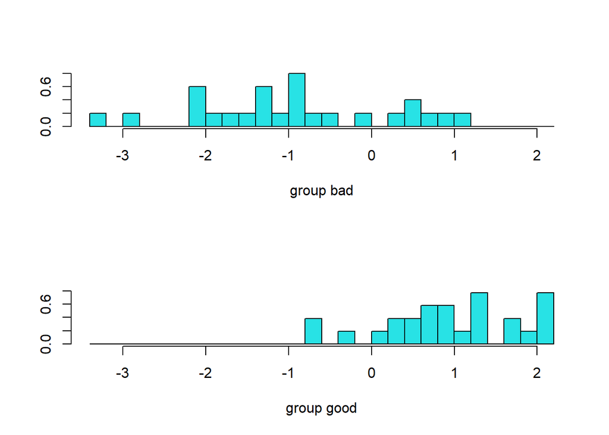

```r
plot(rg)
```

### Inference

- Here we can observe that there is a lot of overlap between the two. There are a lot of residuals.

### For the training data

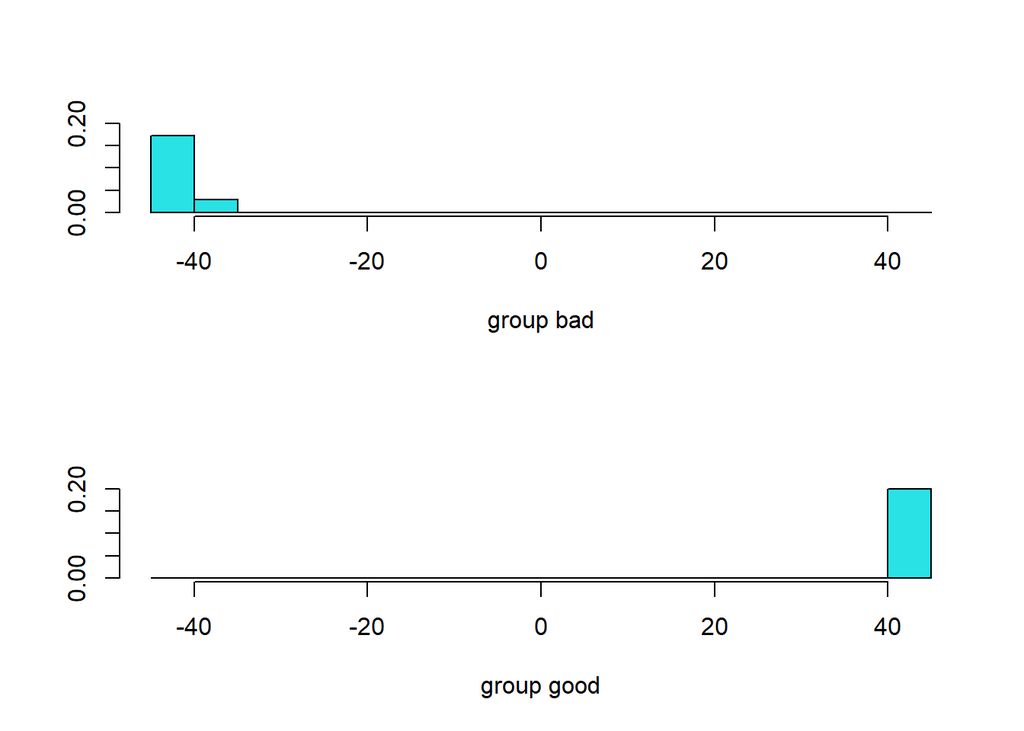

```r
plot(rg3)
```

### Inference

- Here, we can see that all the observations are in one line and there is no overlap.

### Visualization

```r
training_sample1 <- sample(c(TRUE, FALSE), nrow(apples4), replace = T, prob = c(0.75,0.25))
train1 <- apples4[training_sample1, ]
test1 <- apples4[!training_sample1, ]
#lets run LDA like before
apples4[is.na(apples4)] <- mean(apples4, na.rm = TRUE)
```

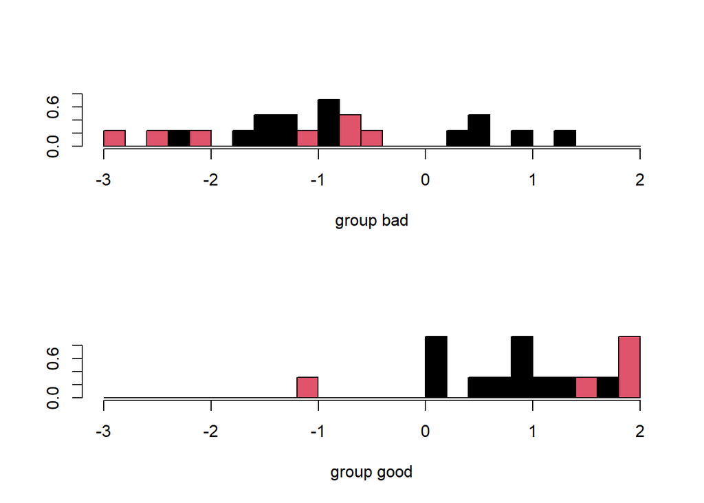

```r
lda.apples4 <- lda(Quality ~ ., train1)
# do a quick plot to understand how good the model is
plot(lda.apples4, col = as.integer(train1$Quality))
```

### Inference

- Here we can observe that there is a lot of overlap between the two. There are a lot of residuals.

### Accuracy

```r
lda.train1 <- predict(lda.apples4)
train1$lda <- lda.train1$class
table(train1$lda,train1$Quality)
```

```
##
##        bad good
##   bad   16    4
##   good   5   12
```

### Inference

- We can see that the accuracy of the model is not that great because there are quite a few wrong predictions.

### Accuracy on test data

```r
lda.test1 <- predict(lda.apples4,test1)
test1$lda <- lda.test1$class
table(test1$lda,test1$Quality)
```

```
##
##        bad good
##   bad    2    3
##   good   2    7
```